# Classify Domains

Nick Allen

October 8, 2014

### Features

How well can we distinguish the classes based on the existing feature set?

```r
d <- domains [source %nin% c('alexa','quantcast')]
```

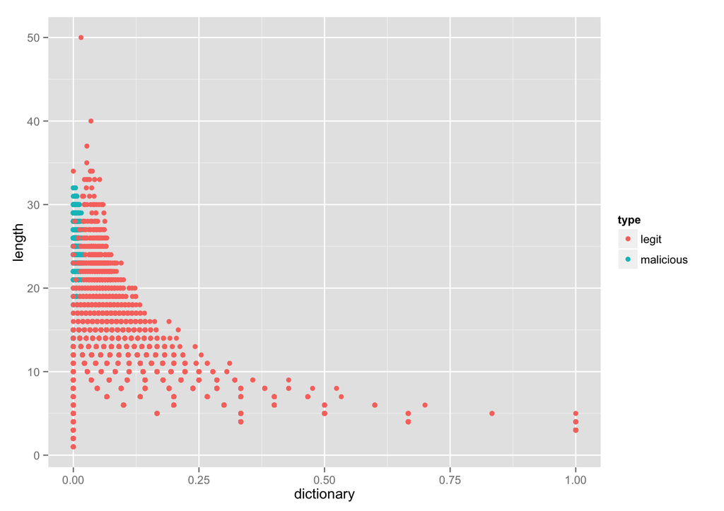

```r
ggplot (d, aes (dictionary, length, colour = type)) + geom_point()
```

### Classification

A rough pass at classifying domains as either legit or malicious based on the current feature set. A portion of the data is held-out at random for cross-validation.

```r
# create a model with only a subset of all domains for expediancy
index <- createDataPartition(domains$type, p = .2, list = FALSE, times = 1) [, 1]
model <- train_classifier (type ~ length + dictionary, domains [index], p = 0.80)
```

```r
model
```

```
## Stochastic Gradient Boosting
##
## 404037 samples
##      6 predictor
##      2 classes: 'legit', 'malicious'
##
## Pre-processing: centered, scaled
## Resampling: Bootstrapped (5 reps)
##
## Summary of sample sizes: 404037, 404037, 404037, 404037, 404037
##
## Resampling results across tuning parameters:
##
##   interaction.depth  n.trees  ROC  Sens  Spec  ROC SD  Sens SD  Spec SD
##   1                   50      1.0  1     0.5   0.002   3e-05    0.02
##   1                  100      1.0  1     0.5   0.002   4e-05    0.03
##   1                  150      1.0  1     0.5   0.002   3e-05    0.03
##   2                   50      0.8  1     0.3   0.180   4e-05    0.22
##   2                  100      0.8  1     0.3   0.180   4e-05    0.22
##   2                  150      0.8  1     0.3   0.180   4e-05    0.22
##   3                   50      0.8  1     0.4   0.194   1e-04    0.20
##   3                  100      0.7  1     0.3   0.204   5e-03    0.21
##   3                  150      0.6  1     0.3   0.141   5e-03    0.16
##
## Tuning parameter 'shrinkage' was held constant at a value of 0.1
## ROC was used to select the optimal model using  the largest value.
## The final values used for the model were n.trees = 150,
##  interaction.depth = 1 and shrinkage = 0.1.
```

How accurate is the classifier?

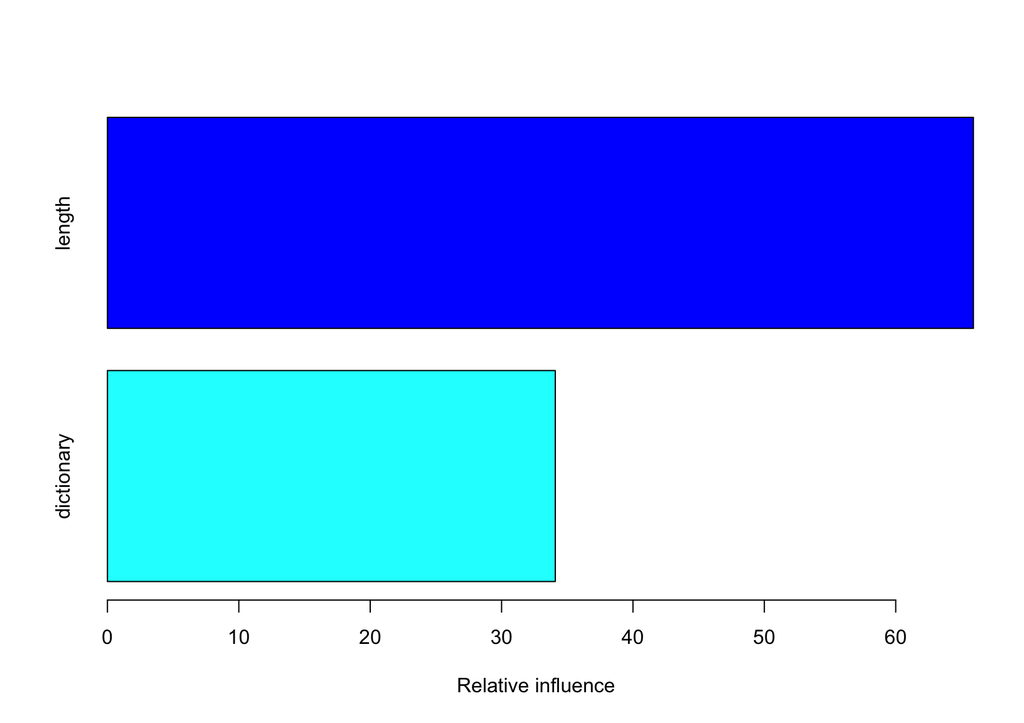

```
##                   var rel.inf
## length         length   65.91
## dictionary dictionary   34.09
```

```r
summary (model)
```

Are there any issues with either sensitivity or specificity?

```r
confusionMatrix (model, positive = "malicious")
```

```
## Bootstrapped (5 reps) Confusion Matrix
##
## (entries are percentages of table totals)
##
##            Reference
## Prediction  legit malicious
##   legit      99.7       0.1
##   malicious   0.0       0.1
```

### Real-World Classification

When such a model is applied in the real-world, the more challenging scenario is when a completely new malware implementation is encountered. In this scenario there is no training data specific to the new maleware. The following assesses accuracy based on this more difficult scenario.

Step 1: Create a training data set using Goz and Cryptolocker.

```r
trainer <- domains [ source %in% c ("goz",
                                    "cryptolocker",
                                    "opendns-random-10k",
                                    "opendns-top-10k")]
```

Step 2: Train a model using all of the training data available from Goz and Cryptolocker.

```r
model <- train_classifier (type ~ length + dictionary, trainer, p = 1.0, n = 10)
```

```r
model
```

```
## Stochastic Gradient Boosting
##
## 23334 samples
##     6 predictor
##     2 classes: 'legit', 'malicious'
##
## Pre-processing: centered, scaled
## Resampling: Bootstrapped (10 reps)
##
## Summary of sample sizes: 23334, 23334, 23334, 23334, 23334, 23334, ...
##
## Resampling results across tuning parameters:
##
##   interaction.depth  n.trees  ROC  Sens  Spec  ROC SD  Sens SD  Spec SD
##   1                   50      1    1     0.9   8e-04   0.002    0.009
##   1                  100      1    1     0.9   6e-04   0.001    0.006
##   1                  150      1    1     0.9   6e-04   0.001    0.006
##   2                   50      1    1     0.9   4e-04   0.001    0.008
##   2                  100      1    1     0.9   3e-04   0.001    0.010
##   2                  150      1    1     0.9   3e-04   0.001    0.009
##   3                   50      1    1     0.9   5e-04   0.002    0.009
##   3                  100      1    1     0.9   3e-04   0.001    0.009
##   3                  150      1    1     1.0   3e-04   0.001    0.005
##
## Tuning parameter 'shrinkage' was held constant at a value of 0.1
## ROC was used to select the optimal model using  the largest value.
## The final values used for the model were n.trees = 150,
##  interaction.depth = 2 and shrinkage = 0.1.
```

Step 3: Use the training results to select an alternate probability cutoff for class membership.

```r
# extract the model probabilities aka confidence
confidence <- predict (model, newdata = trainer, type = "prob") [["malicious"]]

# select an alternative cutoff based on the ROC
curve <- roc (response = trainer$type, predictor = confidence)
cutoff <- coords (curve, x = "best", best.method = "youden")
```

```r
cutoff
```

```
##   threshold specificity sensitivity
##      0.2142      0.9777      0.9829
```

Step 4: Create a hold-out test data set as if Newgoz has never been encountered and is new in the wild. Also, use a completely different set of ‘legit’ domains from Alexis.

```r
tester <- domains [ source %in% c ("newgoz", "alexa")]
```

Step 5: Use the model to determine the probability of being malicious.

```r
confidence <- predict (model, newdata = tester, type = "prob")
tester$type.prob <- confidence [["malicious"]]
```

Step 6: Use the model’s probability and the alternative cutoff to perform final classification.

```r
tester [type.prob > cutoff[["threshold"]], type.hat := "malicious"]
tester [is.na (type.hat), type.hat := "legit"]
tester [, type.hat := as.factor (type.hat)]
```

### Diagnostics

What do the results look-like?

```r
with (tester, confusionMatrix (type, type.hat, positive = "malicious"))
```

```
## Confusion Matrix and Statistics
##
##            Reference
## Prediction   legit malicious
##   legit     970085     29915
##   malicious      0      1666
##
##                Accuracy : 0.97
##                  95% CI : (0.97, 0.97)
##     No Information Rate : 0.968
##     P-Value [Acc > NIR] : <2e-16
##
##                   Kappa : NA
##  Mcnemar's Test P-Value : <2e-16
##
##             Sensitivity : 0.05275
##             Specificity : 1.00000
##          Pos Pred Value : 1.00000
##          Neg Pred Value : 0.97008
##              Prevalence : 0.03153
##          Detection Rate : 0.00166
##    Detection Prevalence : 0.00166
##       Balanced Accuracy : 0.52638
##
##        'Positive' Class : malicious
##
```

Let’s explore the trade-off between sensitivity and specificity. First, capture the class probabilities from the model

```r
# extract the model probabilities aka confidence
confidence <- predict (model, newdata = tester, type = "prob") [["malicious"]]
tester$type.prob <- confidence
```

What do the confidence levels look-like for each type of domain?

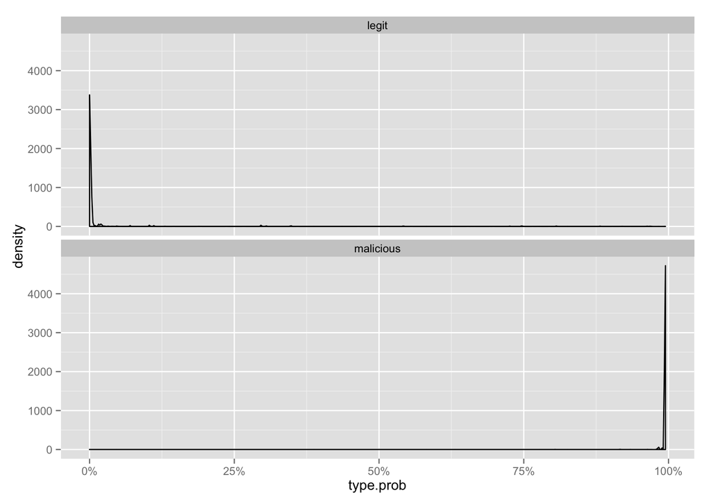

```r
ggplot (tester, aes (type.prob)) +
    geom_density () +
    scale_x_continuous (labels=percent) +
    facet_wrap (~ type, ncol = 1)
```

Classify the (mis)prediction as a true positive, false positive, etc.

```r
tester [type == "malicious" & type.hat == "malicious", outcome := "True Positive"]
tester [type == "legit" & type.hat == "malicious", outcome := "False Positive"]
tester [type == "legit" & type.hat == "legit", outcome := "True Negative"]
tester [type == "malicious" & type.hat == "legit", outcome := "False Negative"]
```

What do the confidence levels look-like for each?

```
## stat_bin: binwidth defaulted to range/30. Use 'binwidth = x' to adjust this.
## stat_bin: binwidth defaulted to range/30. Use 'binwidth = x' to adjust this.
## stat_bin: binwidth defaulted to range/30. Use 'binwidth = x' to adjust this.
```

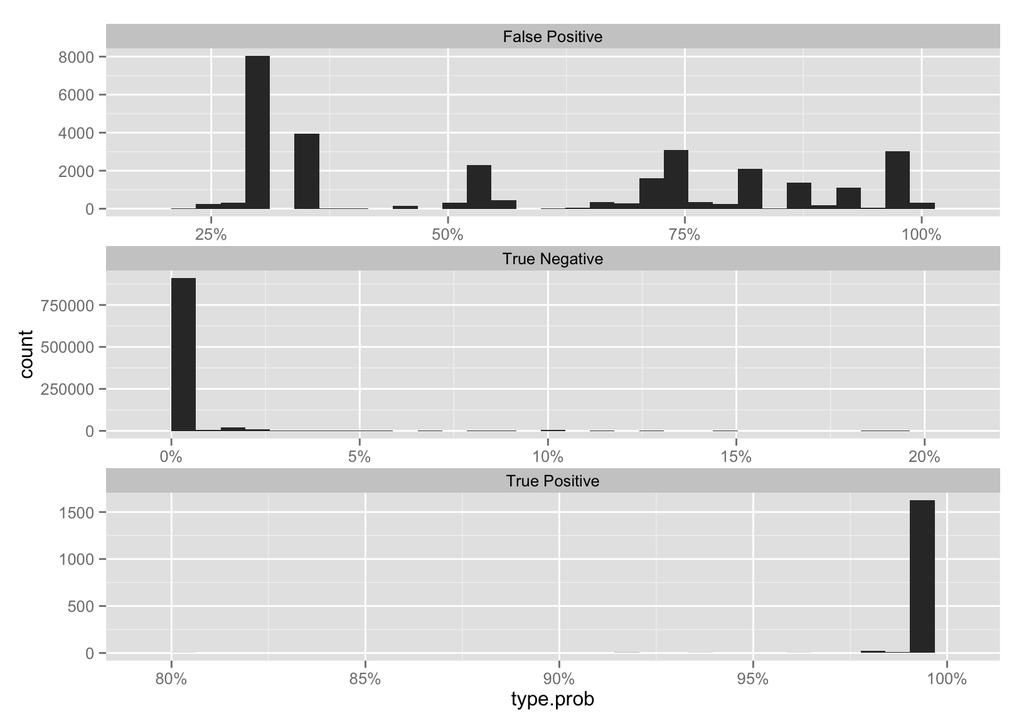

```r
ggplot (tester, aes (type.prob)) +
    geom_histogram () +
    scale_x_continuous (labels=percent) +
    facet_wrap (~ outcome, scales = "free", ncol = 1)
```